# Workflow to extract tree height from Lidar CHM

Author

G. Bediaga

Published

January 8, 2026

# Introduction

This is a pilot test script to extract tree height from a Canopy Height Model (CHM) generated from LiDAR-derived point clouds in a forest management area. Two CHMs will be used: one from the year before harvesting (2015) and one from the year after (2017). The Forest Inventory of the area will also be used. The goal is to identify the crown of the harvested tree and obtain its height from the CHM metrics.

# Lecture

- CHM generation: Fischer et al. (2024).

# Setup

You need `terra` package to handle spatial data and `dplyr` to manipulate tabular data.

```r
library(terra)
library(dplyr)
```

## Working directories

First we set our working directories: the main one, the output, the location of CHMs, and the location of Forest Inventory.

```r
setwd("C:/Gustavo/Doutorado/Dados/UPAS da pesquisa/Jamari/Piloto delimit copa")

dir.lidar <- "D:/Lidar/Script/output/Jamari"

lid.antes <- "C:/Gustavo/Doutorado/Dados/Lidar/Fischer/processado_pelo_Fischer/Jamari/2015/JAM01_2015_chm_lspikefree.tif"

lid.depois <- "C:/Gustavo/Doutorado/Dados/Lidar/Fischer/processado_pelo_Fischer/Jamari/2017/JAM02_2017_chm_lspikefree.tif"

if100_pesquisa <- "C:/Gustavo/Doutorado/Dados/UPAS da pesquisa/Jamari/if100_com_romaneio.csv"
```

## Parameters

Then we set the script parameters.

**lim_inf** = Percentage points threshold to be considered as a gap. When subtracting two CHMs the output difference can be full of noises (a branch that broke or moved for example). Setting a threshold ensures we will select only the large differences.

**pol_area** = Minimum area to be considered as a gap (m<sup>2</sup>).

**projection** = Projection of spatial data.

**buffer_size** = Buffer size around each tree to avoid confusing very close trees and also to identify the associated gap.

**percentil** = Percentile used to extract maximum height in the identified canopy area.

**upa.piloto** = Annual Production Unit used in this test.

**umf** = Forest Management Unit used in this test.

```r
lim_inf <- 0.05

pol_area <- 25

projection <- "EPSG:31980"

buffer_size <- 20

percentil <- 0.95

upa.piloto <- "6"

umf <- "1"
```

# Data

The CHMs were generated by Fabian Fischer from Brazilian Forest Concessions Lidar data, using the method described in Fischer et al. (2024).

Commercial inventories were obtained from Brazilian Forest Concessions.

# Running Code

## CHM processing

Load the CHMs and assign the projection.

```r
r1 <- rast(lid.antes)
r2 <- rast(lid.depois)

crs(r1) <- projection
crs(r2) <- projection
```

Clip the CHMs intersection area.

```r
ext_intersect <- terra::intersect(ext(r1), ext(r2))

r1_crop <- crop(r1,
                ext_intersect)
r2_crop <- crop(r2,
                ext_intersect)
```

```r
diff_raster <- r2_crop - r1_crop

diff_raster <- mask(diff_raster,
                    (!is.na(r1_crop) & !is.na(r2_crop)))
```

Visualize the result.

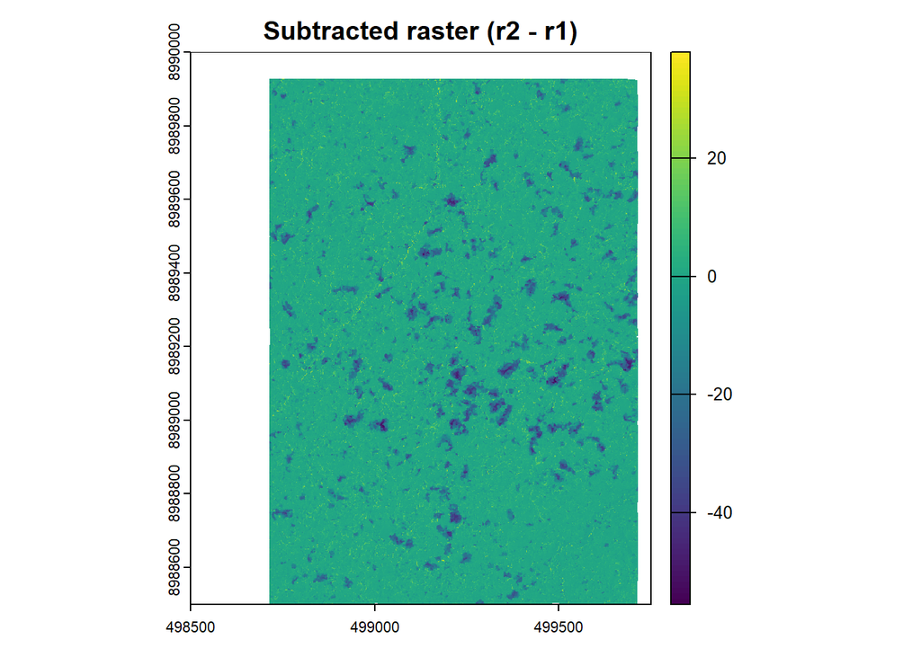

```r
plot(diff_raster,
     main = "Subtracted raster (r2 - r1)")
```

Keep only the higher differences between the two CHMs, to ensure that are really gaps from the exploitation, using the threshold defined before (lim_inf).

```r
q1 <- quantile(values(diff_raster),
               probs = lim_inf,
               na.rm = TRUE)

r_low <- diff_raster
r_low[diff_raster > q1] <- NA
r_low[!is.na(r_low)] <- 1
```

Visualize the filtered result

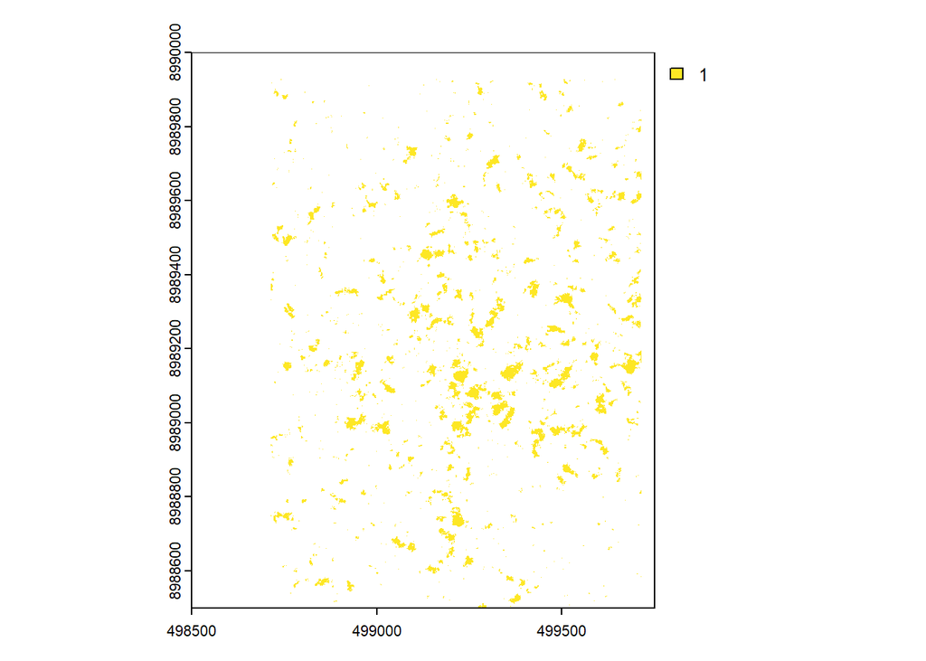

```r
plot(r_low)
```

Convert the result to polygons, project them, calculate area and filter them using the minimum area defined before (pol_area).

```r
r_low_patches <- patches(r_low, directions = 8)
poly_low <- as.polygons(r_low_patches,
                        dissolve = T,
                        na.rm = TRUE)

crs(poly_low) <- projection

poly_low$area_m2 <- expanse(poly_low,
                            unit = "m")

poly_filtrado <- poly_low[poly_low$area_m2 > pol_area, ]
```

Visualizing the results.

The original raster (r2 - r1).

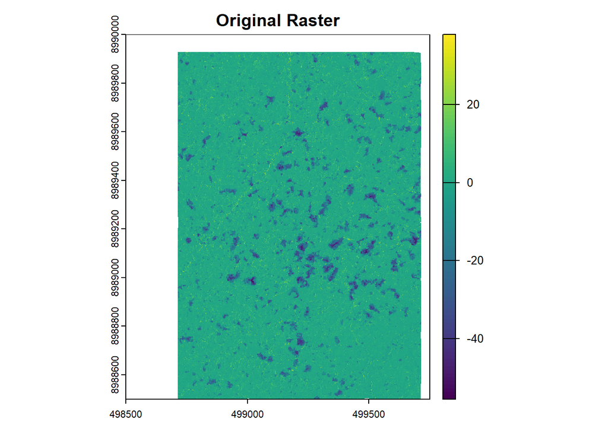

```r
plot(diff_raster,
     main = "Original Raster")
```

All the gaps.

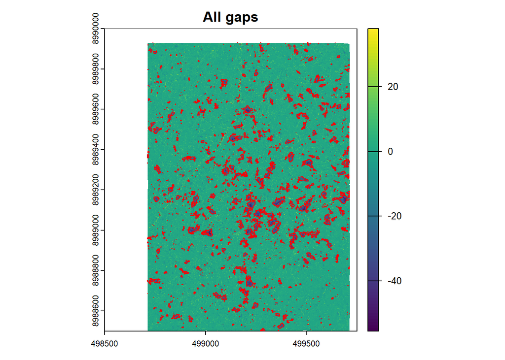

```r
plot(diff_raster,
     main = "All gaps")
plot(poly_low,
     border = "red",
     add = T)
```

The filtered gaps (area > 25 m<sup>2</sup>).

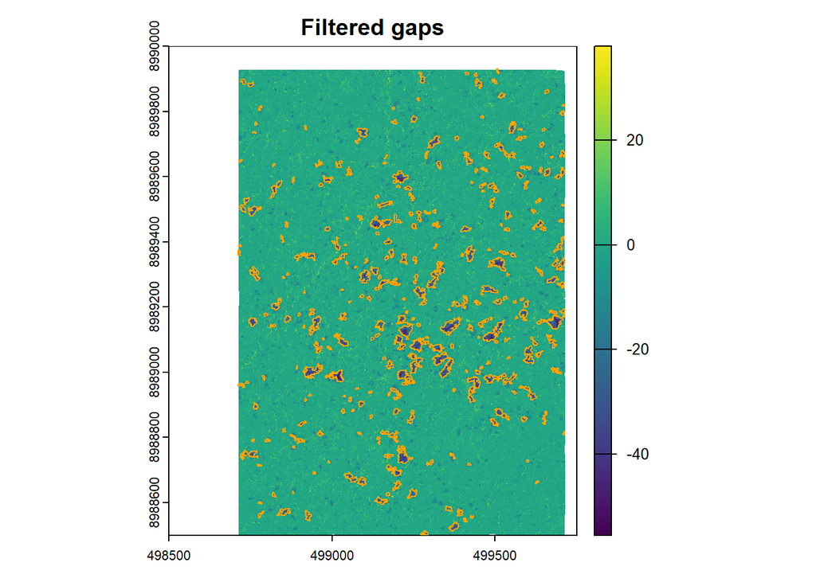

```r
plot(diff_raster,
     main = "Filtered gaps")
plot(poly_filtrado,
      add = T,
      border = "orange")
```

## Forest Inventory

Load the Commercial Forest Inventory, subset it to the pilot APU, and filter it to include only the harvested trees. Then convert it to a spatial vector, project it to the defined CRS and clip it using raster the extent.

```r
if100_romaneio <- read.csv(if100_pesquisa)

if100_upa <- subset(if100_romaneio,
                    codigo == paste0("Jamari_",
                                     "UMF_",
                                     umf,
                                     "_UPA_",
                                     upa.piloto))

if100_upa <- if100_upa[!is.na(if100_upa$vol_tora), ]

if100_pts <- vect(if100_upa,
                  geom = c("lon", "lat"),
                  keepgeom = TRUE,
                  crs = "EPSG:4674")

crs(if100_pts) <- "EPSG:4674"

if100_pts <- project(if100_pts,
                     projection)

if100_pts <- crop(if100_pts,
                  diff_raster)
```

Plot the filtered gaps and the exploited trees.

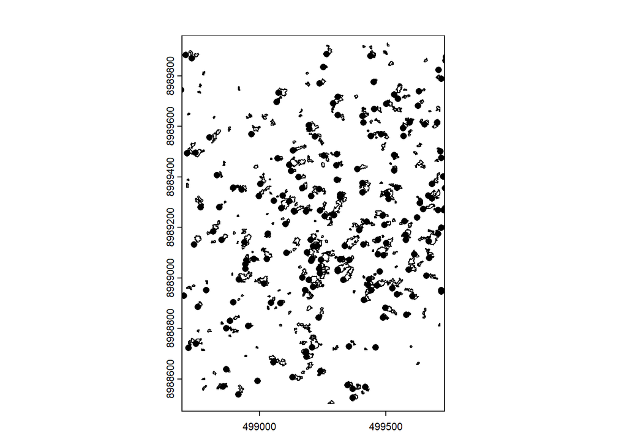

```r
plot(poly_filtrado)
plot(if100_pts,
     add = T)
```

Create an ID for each tree and generate a buffer around them using the buffer size defined earlier. The buffer is intended to prevent confusion between trees that are too close, which could lead to selecting the wrong crown.

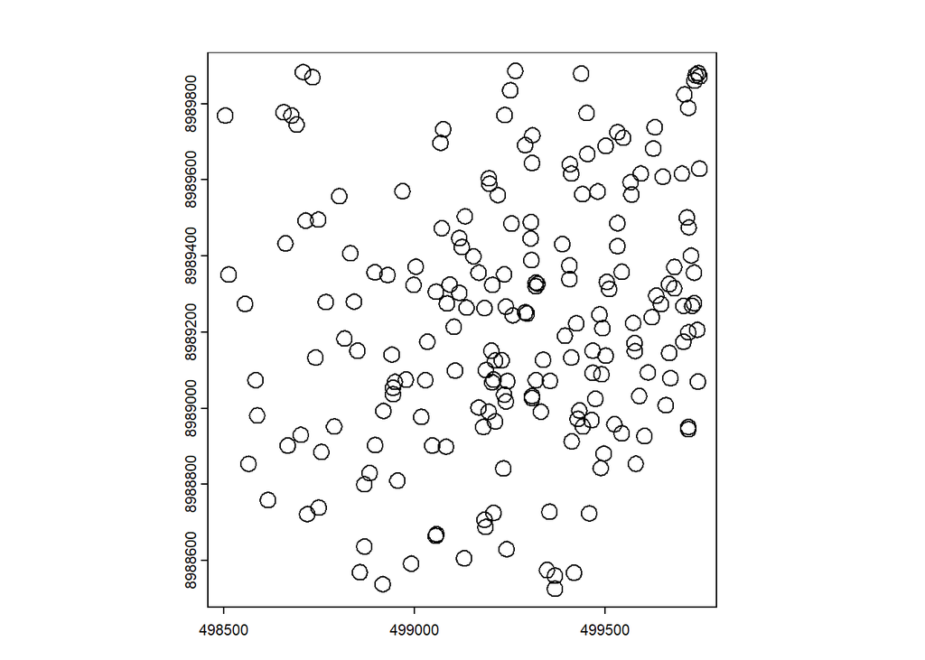

```r
if100_pts$ID <- 1:nrow(if100_pts)

buffer_if100 <- buffer(if100_pts,
                       width = buffer_size)

plot(buffer_if100)
```

Remove the buffers that touch each other so that only isolated trees remain.

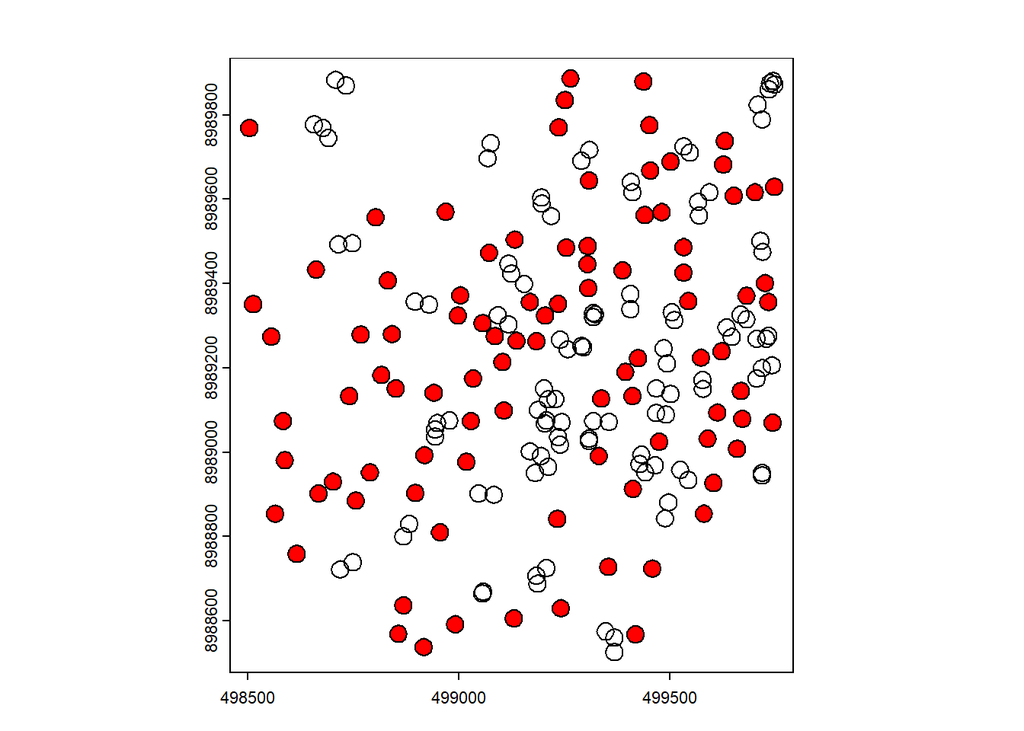

```r
toca <- relate(buffer_if100,
               buffer_if100,
               "overlaps")

diag(toca) <- FALSE

tocam_outros <- apply(toca, 1, any)

b_isolados <- buffer_if100[!tocam_outros]

plot(buffer_if100)
plot(b_isolados,
     add= T,
     col = "red")
```

Select the gaps that intersect with the tree buffers. Sometimes more than one gap intersects the same tree buffer, so we will select the gap whose boundary is closest to the tree.

```r
pts_sel <- if100_pts[ if100_pts$id_arv %in% b_isolados$id_arv , ]

sel <- relate(poly_filtrado, b_isolados, "intersects")

lista_copas <- apply(sel, 2, function(x) which(x))

idx_mantidos <- c()

for (i in seq_along(lista_copas)) {

  copas_idx <- lista_copas[[i]]

  if (length(copas_idx) == 0) next

  if (length(copas_idx) == 1) {
    idx_mantidos <- c(idx_mantidos,
                      copas_idx)
    next
  }

  distancias <- distance(
    pts_sel[i, ],
    poly_filtrado[copas_idx, ]
  )


  idx_melhor <- copas_idx[ which.min(distancias) ]
  idx_mantidos <- c(idx_mantidos,
                    idx_melhor)
}


idx_mantidos <- unique(idx_mantidos)

pol_copas_sel <- poly_filtrado[idx_mantidos, ]
```

Visualize the results. Gray polygons are the gaps, blue polygons are the buffers and red are the gaps that intersects the buffers.

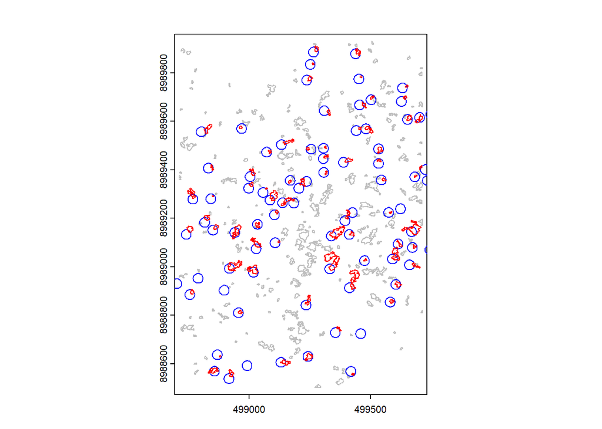

```r
plot(poly_filtrado,
     border = "gray")
plot(b_isolados,
     border = "blue",
     add = TRUE)
plot(pol_copas_sel,
     border = "red",
     add = TRUE)
```

Relate each gap to its intersecting crown so that every gap receives a tree ID.

```r
m <- relate(pol_copas_sel, b_isolados, "intersects")

idx <- apply(m, 1, function(x) ifelse(any(x), which(x)[1], NA))

pol_copas_sel$ID_B <- b_isolados$ID[idx]
```

Visualize the results. Gaps are in blue, buffers in red. Each gap has an tree ID.

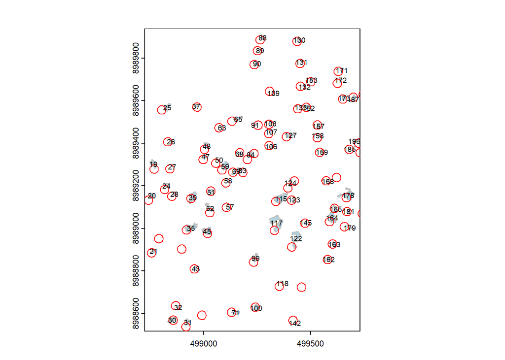

```r
plot(pol_copas_sel,
     col = "lightblue",
     border = "gray")
plot(b_isolados,
     border = "red",
     add = TRUE)
text(pol_copas_sel,
     "ID_B",
     cex = 0.6)
```

## Extracting heights

Extract height values from the pre-harvest CHM using the delimited gaps. Use the maximum height based on the previously defined percentile to avoid outliers and points that do not represent the actual tree height (such as an emerging branch, for example).

```r
valores <- terra::extract(r1,
                          pol_copas_sel)

valores <- na.omit(valores)

colnames(valores) <- c("id_pol", "z")

stats <- valores %>%
  group_by(id_pol) %>%
  summarise(z_max = quantile(z,
                             percentil,
                             na.rm = TRUE))

pol_copas_sel$z_max <- stats$z_max
```

Add the tree height column to the Forest Inventory table.

```r
if100_pts_df <- as.data.frame(if100_pts)
pol_copas_sel_df <- as.data.frame(pol_copas_sel)

if100_pts_z <- left_join(if100_pts_df,
                         pol_copas_sel_df,
                         by = c("ID" = "ID_B"))
```

## Results

Voilà. Final data frame has the tree total height obtained with Lidar.

Let`s write it down, and may the analysis begin.

```r
write.csv(if100_pts_z,
          file = "if100_pts_z.csv")
```

## Graphics

Some plots to see the relations between total height (obtained by Lidar) and commercial height (from the forest inventory) and log lenght (from the logbook)

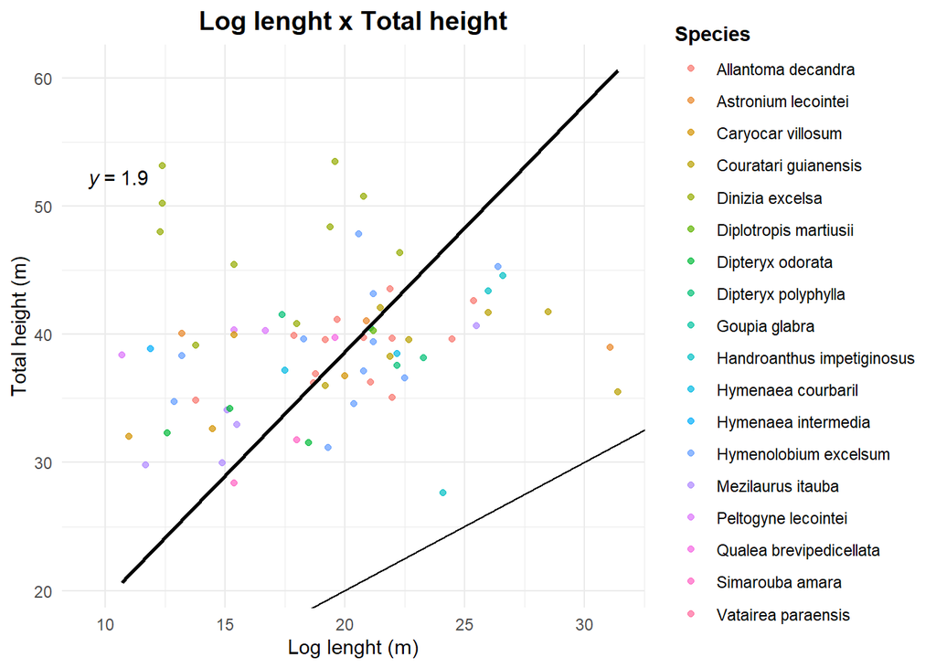

```r
library(ggplot2)
ggplot(if100_pts_z,
       aes(x = comprim_tora,
           y = z_max)) +
  geom_point(alpha = 0.7,
             aes(color = nome_cientifico)) +
  geom_smooth(method = "lm",
              se = FALSE,
              color = "black",
              formula = 'y ~ 0 + x') +
  theme_minimal() +
  labs(
    title = "Log lenght x Total height",
    x = "Log lenght (m)",
    y = "Total height (m)",
    color = "Species"
  ) +
  theme(
    plot.title = element_text(hjust = 0.5,
                              size = 14,
                              face = "bold"),
    legend.title = element_text(face = "bold")
  ) +
  geom_abline() +
  ggpubr::stat_regline_equation(formula = 'y ~ 0 + x')
```

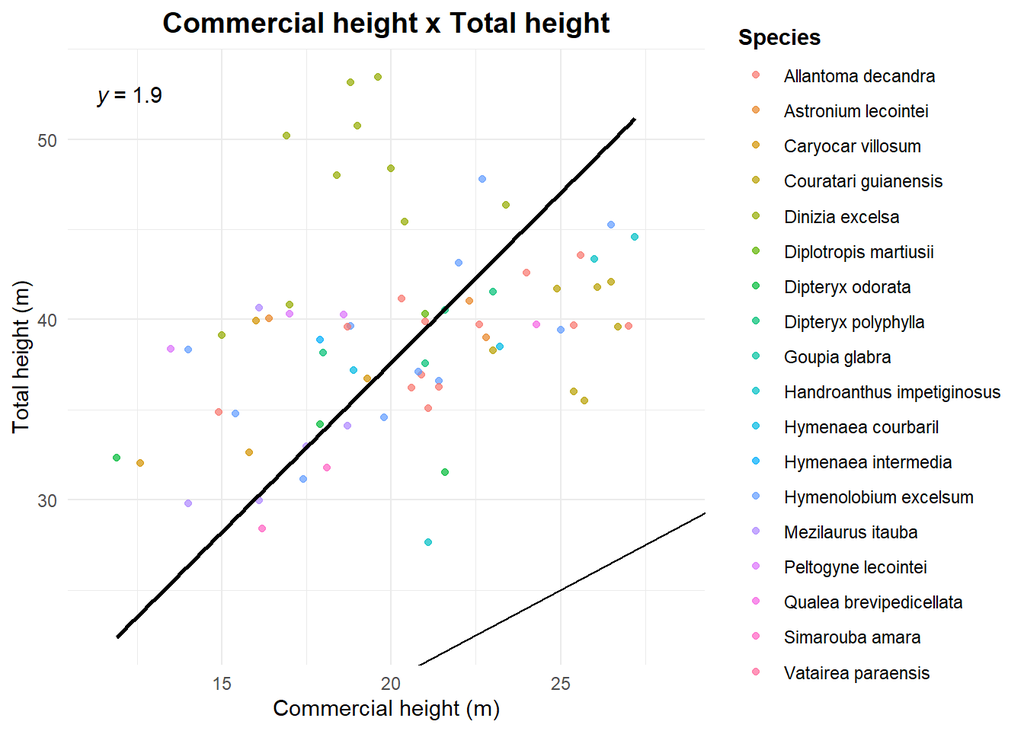

```r
ggplot(if100_pts_z,
       aes(x = altura,
           y = z_max)) +
  geom_point(alpha = 0.7,
             aes(color = nome_cientifico)) +
  geom_smooth(method = "lm",
              se = FALSE,
              color = "black",
              formula = 'y ~ 0 + x') +
  theme_minimal() +
  labs(
    title = "Commercial height x Total height",
    x = "Commercial height (m)",
    y = "Total height (m)",
    color = "Species"
  ) +
  theme(
    plot.title = element_text(hjust = 0.5,
                              size = 14,
                              face = "bold"),
    legend.title = element_text(face = "bold")
  ) +
  geom_abline() +
  ggpubr::stat_regline_equation(formula = 'y ~ 0 + x')
```

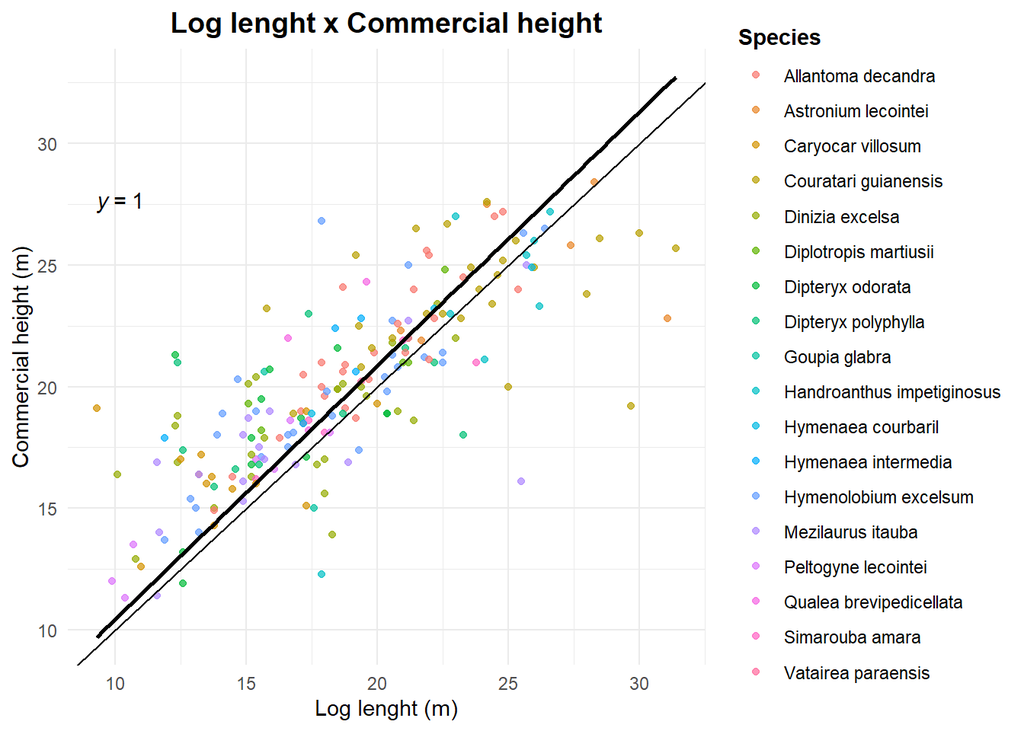

```r
ggplot(if100_pts_z,
       aes(x = comprim_tora,
           y = altura)) +
  geom_point(alpha = 0.7,
             aes(color = nome_cientifico)) +
  geom_smooth(method = "lm",
              se = FALSE,
              color = "black",
              formula = 'y ~ 0 + x') +
  theme_minimal() +
  labs(
    title = "Log lenght x Commercial height",
    x = "Log lenght (m)",
    y = "Commercial height (m)",
    color = "Species"
  ) +
  theme(
    plot.title = element_text(hjust = 0.5,
                              size = 14,
                              face = "bold"),
    legend.title = element_text(face = "bold")
  ) +
  geom_abline() +
  ggpubr::stat_regline_equation(formula = 'y ~ 0 + x')
```

## References

Fischer, Fabian Jörg, Toby Jackson, Grégoire Vincent, and Tommaso Jucker. 2024. “Robust Characterisation of Forest Structure from Airborne Laser Scanning—a Systematic Assessment and Sample Workflow for Ecologists.” *Methods in Ecology and Evolution* 15 (October): 1873–88. https://doi.org/10.1111/2041-210X.14416.